# 1. Business and data understanding

### 3.1.3 Relation between num_voted_users and imdb_score

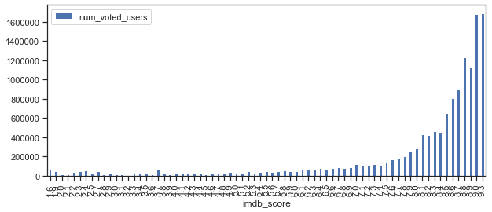

```python
## Relation between number of facebook likes and imdb_score
mvdata.groupby('imdb_score')['num_voted_users'].mean().plot(kind='bar',figsize=(10,4))
plt.legend()
```

### 3.1.4 Relation between Budget and Gross for the top 100 highest gross movies

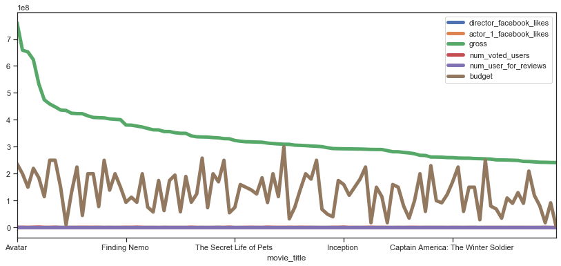

```python
## IMDB Rating correlations with other film attributes
mvdata.groupby('movie_title')['director_facebook_likes','actor_1_facebook_likes','gross','num_voted_users','num_user_for_reviews','budget'].sum().sort_values(by='gross', ascending=False).head(100).plot(kind='line',figsize=(14,6),linewidth=5.0)
#plt.legend()
```

### 3.1.5 Relation between Budget and Gross for top 100 lowest gross movies

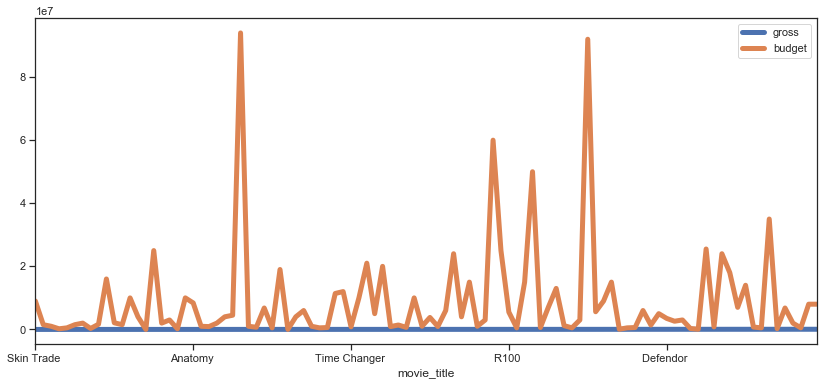

```python
## IMDB Rating correlations with other film attributes
mvdata.groupby('movie_title')['gross','budget'].sum().sort_values(by='gross', ascending=True).head(100).plot(kind='line',figsize=(14,6),linewidth=5.0)
#plt.legend()
```

- Budget of the movie doesn't seem to play important role in success of movie, because gross is almost same for all the movies made with various range of budgets.

### 3.1.6 Top 20 directors with highest average IMDB score

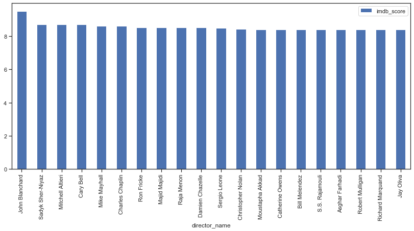

```python
## IMDB Rating correlation with other facenumber_in_poster
mvdata_v.groupby('director_name')['imdb_score'].mean().sort_values(ascending=False).head(20).plot(kind='bar',figsize=(14,6))
plt.legend()
```

- John blachard is the top most hollywood director with highest imdb average score.

### 3.1.7 Top 20 language with highest average IMDB score

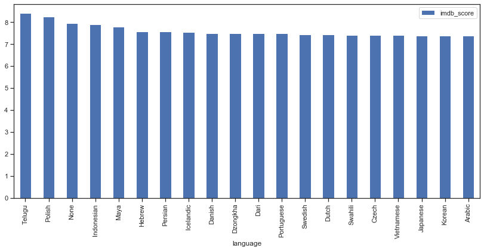

```python
mvdata_v.groupby('language')['imdb_score'].mean().sort_values(ascending=False).head(20).plot(kind='bar',figsize=(14,6))
plt.legend()
```

- Telugu is the top most language with highest imdb average score, which is quite astonishing to know because thats my mother tounge.

```python
mvdata_v.head()
```

|  | color | director_name | num_critic_for_reviews | duration | director_facebook_likes | actor_3_facebook_likes | actor_2_name | actor_1_facebook_likes | gross | genres | ... | num_user_for_reviews | language | country | content_rating | budget | title_year | actor_2_facebook_likes | imdb_score | aspect_ratio | movie_facebook_likes |
| --- | --- | --- | --- | --- | --- | --- | --- | --- | --- | --- | --- | --- | --- | --- | --- | --- | --- | --- | --- | --- | --- |
| 0 | Color | James Cameron | 723.0 | 178.0 | 0.0 | 855.0 | Joel David Moore | 1000.0 | 760505847.0 | Action\|Adventure\|Fantasy\|Sci-Fi | ... | 3054.0 | English | USA | PG-13 | 237000000.0 | 2009.0 | 936.0 | 7.9 | 1.78 | 33000 |
| 1 | Color | Gore Verbinski | 302.0 | 169.0 | 563.0 | 1000.0 | Orlando Bloom | 40000.0 | 309404152.0 | Action\|Adventure\|Fantasy | ... | 1238.0 | English | USA | PG-13 | 300000000.0 | 2007.0 | 5000.0 | 7.1 | 2.35 | 0 |
| 2 | Color | Sam Mendes | 602.0 | 148.0 | 0.0 | 161.0 | Rory Kinnear | 11000.0 | 200074175.0 | Action\|Adventure\|Thriller | ... | 994.0 | English | UK | PG-13 | 245000000.0 | 2015.0 | 393.0 | 6.8 | 2.35 | 85000 |
| 3 | Color | Christopher Nolan | 813.0 | 164.0 | 22000.0 | 23000.0 | Christian Bale | 27000.0 | 448130642.0 | Action\|Thriller | ... | 2701.0 | English | USA | PG-13 | 250000000.0 | 2012.0 | 23000.0 | 8.5 | 2.35 | 164000 |
| 4 | NaN | Doug Walker | NaN | NaN | 131.0 | NaN | Rob Walker | 131.0 | NaN | Documentary | ... | NaN | NaN | NaN | NaN | NaN | NaN | 12.0 | 7.1 | NaN | 0 |

5 rows × 28 columns

# 4.Correlation analysis

• This extends the previous section (business intelligence).  
• Perform correlation analysis and discuss the results. Again, what variables are correlated to imdb_score? How are some key variables correlated to each other?

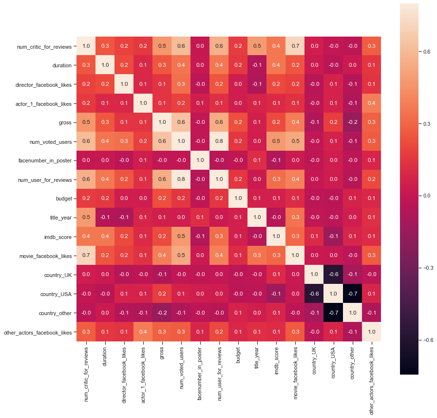

```python
# correlation plot after data cleansing
plt.figure(figsize=(14,14))
sns.heatmap(mvdata.corr(), vmax=.8, square=True, annot=True, fmt=".1f");
```

```python
# Create dummy variables for content_rating
mvdata = pd.get_dummies(mvdata, columns=['content_rating'])
mvdata.head(3)
```

|  | num_critic_for_reviews | duration | director_facebook_likes | actor_1_facebook_likes | gross | movie_title | num_voted_users | facenumber_in_poster | num_user_for_reviews | budget | ... | country_UK | country_USA | country_other | other_actors_facebook_likes | imdb_binned | content_rating_G | content_rating_NC-17 | content_rating_PG | content_rating_PG-13 | content_rating_R |
| --- | --- | --- | --- | --- | --- | --- | --- | --- | --- | --- | --- | --- | --- | --- | --- | --- | --- | --- | --- | --- | --- |
| 0 | 723.0 | 178.0 | 786.665875 | 1000.0 | 760505847.0 | Avatar | 886204 | 1.383742 | 3054.0 | 237000000.0 | ... | 0 | 1 | 0 | 1791.0 | 1 | 0 | 0 | 0 | 1 | 0 |
| 1 | 302.0 | 169.0 | 563.000000 | 40000.0 | 309404152.0 | Pirates of the Caribbean: At World's End | 471220 | 1.383742 | 1238.0 | 300000000.0 | ... | 0 | 1 | 0 | 6000.0 | 1 | 0 | 0 | 0 | 1 | 0 |
| 2 | 602.0 | 148.0 | 786.665875 | 11000.0 | 200074175.0 | Spectre | 275868 | 1.000000 | 994.0 | 245000000.0 | ... | 1 | 0 | 0 | 554.0 | 1 | 0 | 0 | 0 | 1 | 0 |

3 rows × 23 columns

# 5. ML Modeling / Evaluation (& Deployment)

For our modelling process, we will follow a methodology that is greatly highlighted in this infographic.It basically tells us a general thinking process with which we can work with our data modelling:

[figure not shown]

```python
from IPython.display import Image
Image('MLR_Modeling.png')
```

## 5.1 Regression

• Build regression models using at least three different regression algorithms. The Y value is imdb_score. It is important you use important features in your models. • Evaluate the models.

### 5.1.1 Recursive Feature Selection (RFE):

- Feature ranking with recursive feature elimination process - least important features will be pruned from current set of features in each iteration.

```python
#total columns
mvdata.columns
```

```
Index(['num_critic_for_reviews', 'duration', 'director_facebook_likes',
       'actor_1_facebook_likes', 'gross', 'movie_title', 'num_voted_users',
       'facenumber_in_poster', 'num_user_for_reviews', 'budget', 'title_year',
       'imdb_score', 'movie_facebook_likes', 'country_UK', 'country_USA',
       'country_other', 'other_actors_facebook_likes', 'imdb_binned',
       'content_rating_G', 'content_rating_NC-17', 'content_rating_PG',
       'content_rating_PG-13', 'content_rating_R'],
      dtype='object')
```

```python
#select important features using RFE
X = mvdata[['num_critic_for_reviews', 'duration', 'director_facebook_likes',
       'actor_1_facebook_likes', 'gross', 'num_voted_users',
       'facenumber_in_poster', 'num_user_for_reviews', 'budget', 'title_year',
       'movie_facebook_likes', 'country_UK', 'country_USA',
       'country_other', 'other_actors_facebook_likes','content_rating_G', 'content_rating_NC-17', 'content_rating_PG',
       'content_rating_PG-13', 'content_rating_R']]
y = mvdata['imdb_score']
lr = lm.LinearRegression()
rfe = RFE(lr, n_features_to_select=2)
rfe_y = rfe.fit(X,y)

print("Features sorted by their rank:")
print(sorted(zip([x for x in rfe.ranking_], X.columns)))
```

[output not shown]

### 5.1.2 RandormForestRegressor for Feature Selection

- A random forest is an ensemble technique and a meta estimator that fits a number of classifying decision trees on various sub-samples of the dataset and uses averaging to improve the predictive accuracy and control over-fitting

```python
from sklearn.ensemble import RandomForestRegressor
from sklearn.datasets import make_regression

#assigning columns to X and Y variables
X = mvdata[['num_critic_for_reviews', 'duration', 'director_facebook_likes',
       'actor_1_facebook_likes', 'gross', 'num_voted_users',
       'facenumber_in_poster', 'num_user_for_reviews', 'budget', 'title_year',
       'movie_facebook_likes', 'country_UK', 'country_USA',
       'country_other', 'other_actors_facebook_likes','content_rating_G', 'content_rating_NC-17', 'content_rating_PG',
       'content_rating_PG-13', 'content_rating_R']]
y = mvdata['imdb_score']
#X = df.drop(['medv'], axis =1)

fullregr = RandomForestRegressor(n_estimators=100, random_state=0)
fullregr.fit(X, y)
fullregr_predicted = fullregr.predict(X)

print("mean square error: ", mean_squared_error(y, fullregr_predicted))
print("variance or r-squared: ", explained_variance_score(y, fullregr_predicted))
```

```
mean square error:  0.06957007791495205
variance or r-squared:  0.9370494397030756
```

```python
sorted(zip(fullregr.feature_importances_, X.columns))
```

```
[(0.0007060746697642691, 'content_rating_NC-17'),
 (0.0024428284241864206, 'country_UK'),
 (0.0036076199400584662, 'country_other'),
 (0.004245968419866442, 'content_rating_G'),
 (0.004600973899192449, 'content_rating_PG'),
 (0.0059139754999299665, 'content_rating_R'),
 (0.006606456721173945, 'country_USA'),
 (0.011051568924595856, 'content_rating_PG-13'),
 (0.019439934485542966, 'facenumber_in_poster'),
 (0.035236224636026825, 'actor_1_facebook_likes'),
 (0.03728463090532408, 'director_facebook_likes'),
 (0.04176828824115018, 'title_year'),
 (0.04229768144995083, 'other_actors_facebook_likes'),
 (0.04615489500373433, 'num_critic_for_reviews'),
 (0.06510740840947639, 'movie_facebook_likes'),
 (0.06991647698915673, 'num_user_for_reviews'),
 (0.0730717219978186, 'gross'),
 (0.10994885563593734, 'budget'),
 (0.11119192027847612, 'duration'),
 (0.309406495468638, 'num_voted_users')]
```

- **Model: Multiple Regression Analysis taking all X features**

```python
#assigning columns to X and Y variables
X = mvdata[['num_critic_for_reviews', 'duration', 'director_facebook_likes',
       'actor_1_facebook_likes', 'gross', 'num_voted_users',
       'facenumber_in_poster', 'num_user_for_reviews', 'budget', 'title_year',
       'movie_facebook_likes', 'country_UK', 'country_USA',
       'country_other', 'other_actors_facebook_likes','content_rating_G', 'content_rating_NC-17', 'content_rating_PG',
       'content_rating_PG-13', 'content_rating_R']]
y = mvdata['imdb_score']
# We create the model and call it model1.
model = lm.LinearRegression()
# We train the model on our training dataset.
model.fit(X, y)
# Now, we predict points with our trained model.
model_y = model.predict(X)

print("y-intercept ", model.intercept_)

print("mean square error: ", mean_squared_error(y, model_y))
print("variance or r-squared: ", explained_variance_score(y, model_y))

pd.DataFrame(list(zip(X.columns, np.transpose(model.coef_))))
#show coefficeints of all attributes
coef = ["%.3f" % i for i in model.coef_]
xcolumns = [ i for i in X.columns ]
list(zip(xcolumns, coef))
```

```
y-intercept  47.12101423037156
mean square error:  0.6966507942065535
variance or r-squared:  0.36908679092110463
```

```
[('num_critic_for_reviews', '0.002'),
 ('duration', '0.011'),
 ('director_facebook_likes', '0.000'),
 ('actor_1_facebook_likes', '0.000'),
 ('gross', '-0.000'),
 ('num_voted_users', '0.000'),
 ('facenumber_in_poster', '-0.024'),
 ('num_user_for_reviews', '-0.001'),
 ('budget', '-0.000'),
 ('title_year', '-0.021'),
 ('movie_facebook_likes', '-0.000'),
 ('country_UK', '0.124'),
 ('country_USA', '-0.223'),
 ('country_other', '0.099'),
 ('other_actors_facebook_likes', '-0.000'),
 ('content_rating_G', '0.327'),
 ('content_rating_NC-17', '-0.093'),
 ('content_rating_PG', '-0.062'),
 ('content_rating_PG-13', '-0.224'),
 ('content_rating_R', '0.053')]
```

- **Model1: Multiple Regression Analysis taking important X features**

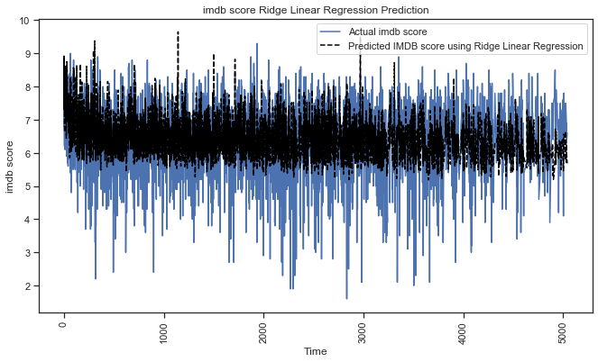

```python
#assigning columns to X and Y variables
X = mvdata[['num_critic_for_reviews', 'duration','facenumber_in_poster', 'title_year','country_UK', 'country_USA',
            'country_other', 'content_rating_G', 'content_rating_NC-17', 'content_rating_PG','content_rating_PG-13', 'content_rating_R']]
y = mvdata['imdb_score']

# We create the model and call it model1.
model1 = lm.LinearRegression()
# We train the model on our training dataset.
model1.fit(X, y)
# Now, we predict points with our trained model.
model1_y = model1.predict(X)

plt.figure(figsize=(11,6))
plt.plot(mvdata['imdb_score'],label="Actual imdb score")
plt.plot(mvdata.index, model1_y, linestyle='--', label="Predicted IMDB score using Ridge Linear Regression",color='black')
plt.xlabel('Time')
plt.ylabel('imdb score')
plt.title("imdb score Ridge Linear Regression Prediction")
plt.xticks(rotation=90)
plt.legend()
```

**Linear Regression Model: y = 64.28 + 0.004 (num_critic_for_reviews) + 0.012 (duration) - 0.018 (facenumber_in_poster) - 0.03 (title_year) - 0.112 (country_USA) + 0.086 (country_other) + 0.41 (content_rating_G)....etc**

- For every one unit increase in 'num_critic_for_reviews' increases imdb_Score by 0.004 on average , holding all other varibales constant.
- For every one unit increase in 'duration' increases imdb_Score by 0.012 on average , holding all other varibales constant.
- For every one unit increase in 'facenumber_in_poster' decreases imdb_Score by 0.018 on average , holding all other varibales constant.

```python
print("mean square error: ", mean_squared_error(y, model1_y))
print("variance or r-squared: ", explained_variance_score(y, model1_y))
```

```
mean square error:  0.7830106249885749
variance or r-squared:  0.29087607412108796
```

- **Ridge regression** : Linear Model trained with L2 prior as regularizer

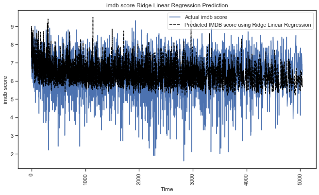

```python
#assigning columns to X and Y variables
X = mvdata[['num_critic_for_reviews', 'duration', 'facenumber_in_poster', 'title_year',
            'country_UK', 'country_USA','country_other', 'content_rating_G', 'content_rating_NC-17',
            'content_rating_PG','content_rating_PG-13', 'content_rating_R']]
y = mvdata['imdb_score']

# split validation
X_train, X_test, y_train, y_test =  train_test_split(X, y, test_size = 0.33, random_state = 0)

# Fit the model using Lasso regression
modelr = lm.Ridge(alpha=1)  #higher alpha (penality parameter), fewer predictors
modelr.fit(X_train, y_train)

#predict the output for test set
modelr_y = modelr.predict(X_test)

#print('Coefficients: ', modelr.coef_)
#print("y-intercept ", modelr.intercept_)
#coef = ["%.3f" % i for i in modelr.coef_]
#xcolumns = [ i for i in X.columns ]
#list(zip(xcolumns, coef))

plt.figure(figsize=(11,6))
modelr_y = modelr.predict(X)
plt.plot(mvdata['imdb_score'],label="Actual imdb score")
plt.plot(mvdata.index, modelr_y, linestyle='--', label="Predicted IMDB score using Ridge Linear Regression",color='black')
plt.xlabel('Time')
plt.ylabel('imdb score')
plt.title("imdb score Ridge Linear Regression Prediction")
plt.xticks(rotation=90)
plt.legend()
```

```python
print("mean square error: ", mean_squared_error(y, modelr_y))
print("variance or r-squared: ", explained_variance_score(y, modelr_y))
```

```
mean square error:  0.7849913416469968
variance or r-squared:  0.2893448759659222
```

- **Support vector machine (SVM):**
- use Support Vector Regression since this is a regression problem.
- most important SVR parameter is Kernel type. It can be #linear, polynomial or gaussian SVR.
- It must be one of ‘linear’, ‘poly’, ‘rbf’, ‘sigmoid’, ‘precomputed’

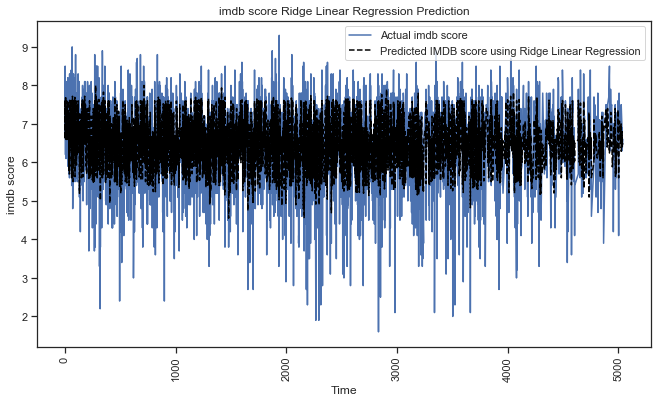

```python
from sklearn.svm import SVR
from sklearn.preprocessing import StandardScaler

#assigning columns to X and Y variables
X = mvdata[['num_critic_for_reviews', 'duration','facenumber_in_poster', 'title_year','country_UK', 'country_USA',
            'country_other', 'content_rating_G', 'content_rating_NC-17', 'content_rating_PG','content_rating_PG-13', 'content_rating_R']]
y = mvdata['imdb_score']

# split validation
X_train, X_test, y_train, y_test =  train_test_split(X, y, test_size = 0.33, random_state = 0)

# we select RBF(a #gaussian type) kernel.
regressor = SVR(kernel='rbf')
regressor.fit(X_train,y_train)

# Predicting a new results for scoring dataset
y_pred = regressor.predict(X_test)

plt.figure(figsize=(11,6))
modelsvr_y = regressor.predict(X)
plt.plot(mvdata['imdb_score'],label="Actual imdb score")
plt.plot(mvdata.index, modelsvr_y, linestyle='--', label="Predicted IMDB score using Ridge Linear Regression",color='black')
plt.xlabel('Time')
plt.ylabel('imdb score')
plt.title("imdb score Ridge Linear Regression Prediction")
plt.xticks(rotation=90)
plt.legend()
```

```python
print("mean square error: ", mean_squared_error(y_test, y_pred))
print("variance or r-squared: ", explained_variance_score(y_test, y_pred))
```

```
mean square error:  1.0180455759892264
variance or r-squared:  0.08107309461390255
```

## 5.2 Classification

• The goal is to build a classification model to predict if a movie is good or bad. You need to create a new “categorical” column from imdb_score in order to build classification models. Create the column by “converting” the imdb_score into 2 categories (or classes): “1~ 5 and 6 ~ 10, which represents bad (or 0) and good (or 1) respectively” 2. • It is important that you use at least three different classification algorithms we have learned and evaluate model quality.

### 5.2.1 **Decision Tree**

```
Accuracy Score: 0.857024106400665
---------------Classification Report:-------------------
              precision    recall  f1-score   support

           0       0.24      0.28      0.26       108
           1       0.93      0.91      0.92      1095

    accuracy                           0.86      1203
   macro avg       0.58      0.60      0.59      1203
weighted avg       0.87      0.86      0.86      1203

AUC Score: 0.5959665144596651
---------------Confusion Matrix-------------------------
[[  30   78]
 [  94 1001]]
```

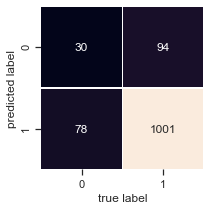

```python
# declare X variables and y variable
X = mvdata[['num_critic_for_reviews', 'duration', 'director_facebook_likes',
       'actor_1_facebook_likes', 'gross', 'num_voted_users',
       'facenumber_in_poster', 'num_user_for_reviews', 'budget', 'title_year',
       'movie_facebook_likes', 'country_UK', 'country_USA',
       'country_other', 'other_actors_facebook_likes','content_rating_G', 'content_rating_NC-17', 'content_rating_PG',
       'content_rating_PG-13', 'content_rating_R']]
y = mvdata['imdb_binned']

# split validation
X_train, X_test, y_train, y_test =  train_test_split(X, y, test_size = 0.33, random_state = 0)

# Initialize DecisionTreeClassifier()
dt = DecisionTreeClassifier()

# Train a decision tree model
dt.fit(X_train,y_train)

#Predict Y values
Y_pred = dt.predict(X_test)

#build confusion materix
fig, ax = plt.subplots(figsize=(3,3))
mat = confusion_matrix(y_test, Y_pred)
sns.heatmap(mat.T, square=True, annot=True, fmt="d", cbar=False, linewidths=.5)
plt.xlabel('true label')
plt.ylabel('predicted label');

print("Accuracy Score:", metrics.accuracy_score(y_test, Y_pred))
print("---------------Classification Report:-------------------")
print(metrics.classification_report(y_test, Y_pred))
print("AUC Score:",metrics.roc_auc_score(y_test,Y_pred))
print("---------------Confusion Matrix-------------------------")
print(metrics.confusion_matrix(y_test, Y_pred))
```

> **86% model accuracy**
> - **0.60 AUC score; AUC = Area Under Curve**

### 5.2.2 Knn

```
Accuracy Score: 0.9010806317539485
---------------Classification Report:-------------------
              precision    recall  f1-score   support

           0       0.13      0.02      0.03       108
           1       0.91      0.99      0.95      1095

    accuracy                           0.90      1203
   macro avg       0.52      0.50      0.49      1203
weighted avg       0.84      0.90      0.87      1203

AUC Score: 0.5033231861998985
---------------Confusion Matrix-------------------------
[[   2  106]
 [  13 1082]]
```

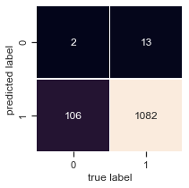

```python
# evaluate the model by splitting into train and test sets & develop knn model (name it as knn)
X = mvdata[['num_critic_for_reviews', 'duration', 'director_facebook_likes',
       'actor_1_facebook_likes', 'gross', 'num_voted_users',
       'facenumber_in_poster', 'num_user_for_reviews', 'budget', 'title_year',
       'movie_facebook_likes', 'country_UK', 'country_USA',
       'country_other', 'other_actors_facebook_likes','content_rating_G', 'content_rating_NC-17', 'content_rating_PG',
       'content_rating_PG-13', 'content_rating_R']]
y = mvdata['imdb_binned']

#develop knn model
X_train, X_test, y_train, y_test =  train_test_split(X, y, test_size = 0.33, random_state = 0)
knn = KNeighborsClassifier()
knn.fit(X_train,y_train)

#Predict Y values
Y_pred = knn.predict(X_test)

#build confusion materix
fig, ax = plt.subplots(figsize=(3,3))
mat = confusion_matrix(y_test, Y_pred)
sns.heatmap(mat.T, square=True, annot=True, fmt="d", cbar=False, linewidths=.5)
plt.xlabel('true label')
plt.ylabel('predicted label');

print("Accuracy Score:", metrics.accuracy_score(y_test, Y_pred))
print("---------------Classification Report:-------------------")
print(metrics.classification_report(y_test, Y_pred))
print("AUC Score:",metrics.roc_auc_score(y_test,Y_pred))
print("---------------Confusion Matrix-------------------------")
print(metrics.confusion_matrix(y_test, Y_pred))
```

> **90% model accuracy**
> - **0.50 AUC score; AUC = Area Under Curve**

```python
# evaluate the knn model using 10-fold cross-validation
scores = cross_val_score(KNeighborsClassifier(), X, y, scoring='accuracy', cv=10)
print(scores)
```

```
[0.90710383 0.77808219 0.8109589  0.85753425 0.87912088 0.74725275
 0.88461538 0.87912088 0.87087912 0.91208791]
```

```python
#create a dictionary of all values we want to test for n_neighbors
params_knn = {'n_neighbors': np.arange(1, 25)}

#use gridsearch to test all values for n_neighbors
knn_gs = GridSearchCV(knn, params_knn, cv=5, iid=False)

#fit model to training data
knn_gs.fit(X_train, y_train)

#save best model
knn_best = knn_gs.best_estimator_

#check best n_neigbors value
print(knn_gs.best_score_)
print(knn_gs.best_params_)
print(knn_gs.best_estimator_)
```

```
0.9086826739933018
{'n_neighbors': 13}
KNeighborsClassifier(algorithm='auto', leaf_size=30, metric='minkowski',
                     metric_params=None, n_jobs=None, n_neighbors=13, p=2,
                     weights='uniform')
```

### 5.2.3 Logistic regression

```python
# declare X variables and y variable
X = mvdata[['num_critic_for_reviews', 'duration', 'director_facebook_likes',
       'actor_1_facebook_likes', 'gross', 'num_voted_users',
       'facenumber_in_poster', 'num_user_for_reviews', 'budget', 'title_year',
       'movie_facebook_likes', 'country_UK', 'country_USA',
       'country_other', 'other_actors_facebook_likes','content_rating_G', 'content_rating_NC-17', 'content_rating_PG',
       'content_rating_PG-13', 'content_rating_R']]
y = mvdata['imdb_binned']

# evaluate the model by splitting into train and test sets and build a logistic regression model
# name it as "lr"
X_train, X_test, y_train, y_test = train_test_split(X, y, test_size=0.3, random_state=0)
lr = LogisticRegression(solver='lbfgs', max_iter=500)
lr.fit(X_train, y_train)


# print coefficients
coef = pd.DataFrame(list(zip(X.columns, np.transpose(lr.coef_))),
             columns=['X variables', 'coef']).sort_values('coef', ascending=False)

coef['coef'] = coef['coef'].str[0]
coef
```

|  | X variables | coef |
| --- | --- | --- |
| 9 | title_year | 1.244567e-04 |
| 10 | movie_facebook_likes | 1.216524e-04 |
| 2 | director_facebook_likes | 3.838517e-05 |
| 14 | other_actors_facebook_likes | 3.107828e-05 |
| 5 | num_voted_users | 2.586198e-05 |
| 3 | actor_1_facebook_likes | 2.391553e-05 |
| 1 | duration | 7.260079e-06 |
| 0 | num_critic_for_reviews | 2.739573e-06 |
| 6 | facenumber_in_poster | 1.159847e-07 |
| 19 | content_rating_R | 5.480483e-08 |
| 12 | country_USA | 3.958386e-08 |
| 13 | country_other | 1.524739e-08 |
| 11 | country_UK | 7.413992e-09 |
| 15 | content_rating_G | 5.404846e-09 |
| 17 | content_rating_PG | 2.522994e-09 |
| 8 | budget | 1.869381e-09 |
| 16 | content_rating_NC-17 | -2.200983e-10 |
| 18 | content_rating_PG-13 | -2.673284e-10 |
| 4 | gross | -9.049365e-09 |
| 7 | num_user_for_reviews | -3.867229e-06 |

```
Accuracy Score: 0.9140767824497258
---------------Classification Report:-------------------
              precision    recall  f1-score   support

           0       0.50      0.01      0.02        94
           1       0.91      1.00      0.96      1000

    accuracy                           0.91      1094
   macro avg       0.71      0.50      0.49      1094
weighted avg       0.88      0.91      0.87      1094

AUC Score: 0.5048191489361702
---------------Confusion Matrix-------------------------
[[  1  93]
 [  1 999]]
```

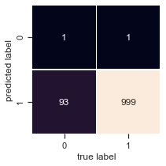

```python
#Predict Y values
Y_pred = lr.predict(X_test)

#build confusion materix
fig, ax = plt.subplots(figsize=(3,3))
mat = confusion_matrix(y_test, Y_pred)
sns.heatmap(mat.T, square=True, annot=True, fmt="d", cbar=False, linewidths=.5)
plt.xlabel('true label')
plt.ylabel('predicted label');

print("Accuracy Score:", metrics.accuracy_score(y_test, Y_pred))
print("---------------Classification Report:-------------------")
print(metrics.classification_report(y_test, Y_pred))
print("AUC Score:",metrics.roc_auc_score(y_test,Y_pred))
print("---------------Confusion Matrix-------------------------")
print(metrics.confusion_matrix(y_test, Y_pred))
```

> **91% model accuracy**
> - **0.50 AUC score; AUC = Area Under Curve**

```python
# evaluate the logistic model using 10-fold cross-validation
scores = cross_val_score(LogisticRegression(solver='lbfgs', max_iter=500), X, y, scoring='accuracy', cv=10)
print("10-fold scores are:",scores)
print("10-fold scores mean:",scores.mean())
```

```
10-fold scores are: [0.90710383 0.90958904 0.90958904 0.90958904 0.90384615 0.90659341
 0.90934066 0.90934066 0.90934066 0.90934066]
10-fold scores mean: 0.9083673146226481
```

### 5.2.3 Random Forest Classifier

```python
from sklearn.ensemble import RandomForestClassifier

clf = RandomForestClassifier(n_estimators=20)    #building 20 decision trees
clf=clf.fit(X_train, y_train)
clf.score(X_test, y_test)
```

```
0.9113345521023766
```

```
Accuracy Score: 0.9113345521023766
---------------Classification Report:-------------------
              precision    recall  f1-score   support

           0       0.43      0.11      0.17        94
           1       0.92      0.99      0.95      1000

    accuracy                           0.91      1094
   macro avg       0.68      0.55      0.56      1094
weighted avg       0.88      0.91      0.89      1094

AUC Score: 0.5466914893617021
---------------Confusion Matrix-------------------------
[[ 10  84]
 [ 13 987]]
```

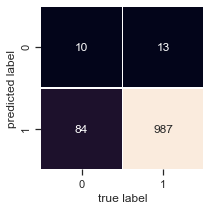

```python
#Predict Y values
Y_pred = clf.predict(X_test)

#build confusion materix
fig, ax = plt.subplots(figsize=(3,3))
mat = confusion_matrix(y_test, Y_pred)
sns.heatmap(mat.T, square=True, annot=True, fmt="d", cbar=False, linewidths=.5)
plt.xlabel('true label')
plt.ylabel('predicted label');

print("Accuracy Score:", metrics.accuracy_score(y_test, Y_pred))
print("---------------Classification Report:-------------------")
print(metrics.classification_report(y_test, Y_pred))
print("AUC Score:",metrics.roc_auc_score(y_test,Y_pred))
print("---------------Confusion Matrix-------------------------")
print(metrics.confusion_matrix(y_test, Y_pred))
```